# Pet Insurance Claim Severity Prediction

## Objective

Develop predictive models to estimate expected pet insurance claim severity using customer, policy and engineered risk variables.

The objective is to compare multiple modelling approaches and identify the most suitable model for pricing and underwriting applications.

## Business Question

Can claim severity be accurately predicted using available policyholder and pet characteristics?

Which modelling approach provides the best predictive performance for estimating expected insurer claim costs?

## Load Data

```python
import pandas as pd
import numpy as np
import matplotlib.pyplot as plt

from sklearn.model_selection import train_test_split

df = pd.read_csv("../data/processed/pet_insurance_claims.csv")

df.shape
```

```
(188318, 142)
```

## Select Features

```python
features = [

    "species",

    "breed",

    "pet_age",

    "coverage_level",

    "excess",

    "breed_risk_factor",

    "age_risk_factor",

    "coverage_risk_factor",

    "excess_risk_factor"

]
```

```python
target = "adjusted_claim_amount"
```

```python
X = df[features]
y = df[target]
```

## Encoding

```python
X = pd.get_dummies(
    X,
    drop_first=True
)
```

## Train Test Split

```python
X_train, X_test, y_train, y_test = train_test_split(

    X,
    y,

    test_size=0.2,

    random_state=42

)
```

```python
print(X_train.shape)
print(X_test.shape)
```

```
(150654, 20)
(37664, 20)
```

## Baseline Model (Linear Regression)

### Objective

Develop a simple Linear Regression model as the baseline benchmark for predicting expected claim severity.

The baseline model provides a reference point for evaluating whether more advanced machine learning algorithms deliver meaningful improvements in predictive performance.

```python
from sklearn.linear_model import LinearRegression

from sklearn.metrics import (
    mean_absolute_error,
    mean_squared_error,
    r2_score
)
```

### Train Linear Regression

```python
linear_model = LinearRegression()

linear_model.fit(
    X_train,
    y_train
)
```

```
LinearRegression(copy_X=True, fit_intercept=True, n_jobs=None, normalize=False)
```

### Prediction

```python
y_pred_lr = linear_model.predict(X_test)
```

### Performance Evaluation

```python
mae = mean_absolute_error(
    y_test,
    y_pred_lr
)

rmse = mean_squared_error(
    y_test,
    y_pred_lr,
    squared=False
)

r2 = r2_score(
    y_test,
    y_pred_lr
)
```

```python
performance = pd.DataFrame({

    "Metric":[
        "MAE",
        "RMSE",
        "R²"
    ],

    "Linear Regression":[
        mae,
        rmse,
        r2
    ]

})

performance
```

|  | Metric | Linear Regression |
| --- | --- | --- |
| 0 | MAE | 2757.519297 |
| 1 | RMSE | 4371.865296 |
| 2 | R² | 0.130945 |

### Visualization

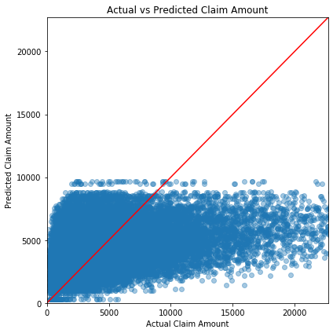

```python
plt.figure(figsize=(6,6))

plt.scatter(
    y_test,
    y_pred_lr,
    alpha=0.4
)

plt.plot(
    [y_test.min(), y_test.max()],
    [y_test.min(), y_test.max()],
    color="red"
)

upper = np.percentile(y_test,99)

plt.xlim(0,upper)
plt.ylim(0,upper)

plt.xlabel("Actual Claim Amount")
plt.ylabel("Predicted Claim Amount")

plt.title("Actual vs Predicted Claim Amount")

plt.tight_layout()

plt.show()
```

### Observation

The Linear Regression model explains only a modest proportion of claim severity variation (R² = 0.13).

The scatter plot shows that predictions are concentrated around the portfolio average, while high-cost claims are consistently underestimated.

This indicates that a simple linear relationship is insufficient to capture the complex and non-linear patterns present in insurance claim severity.

The baseline model therefore provides a useful benchmark for evaluating more advanced machine learning algorithms.

## Decision Tree

### Objective

Develop a Decision Tree Regression model to capture non-linear relationships between policy characteristics and claim severity.

Unlike Linear Regression, Decision Trees partition the feature space into homogeneous regions, enabling more flexible modelling of complex insurance pricing relationships.

The model serves as an intermediate benchmark before ensemble methods such as Random Forest.

### Import Libraries

```python
from sklearn.tree import DecisionTreeRegressor

from sklearn.metrics import (
    mean_absolute_error,
    mean_squared_error,
    r2_score
)
```

### Train Model

```python
tree_model = DecisionTreeRegressor(

    random_state=42

)

tree_model.fit(

    X_train,
    y_train

)
```

```
DecisionTreeRegressor(ccp_alpha=0.0, criterion='mse', max_depth=None,
                      max_features=None, max_leaf_nodes=None,
                      min_impurity_decrease=0.0, min_impurity_split=None,
                      min_samples_leaf=1, min_samples_split=2,
                      min_weight_fraction_leaf=0.0, presort='deprecated',
                      random_state=42, splitter='best')
```

### Prediction

```python
y_pred_tree = tree_model.predict(X_test)
```

### Performance Evaluation

```python
tree_mae = mean_absolute_error(
    y_test,
    y_pred_tree
)

tree_rmse = mean_squared_error(
    y_test,
    y_pred_tree,
    squared=False
)

tree_r2 = r2_score(
    y_test,
    y_pred_tree
)
```

```python
performance["Decision Tree"] = [

    tree_mae,

    tree_rmse,

    tree_r2

]

performance
```

|  | Metric | Linear Regression | Decision Tree |
| --- | --- | --- | --- |
| 0 | MAE | 2757.519297 | 2776.952036 |
| 1 | RMSE | 4371.865296 | 4403.480046 |
| 2 | R² | 0.130945 | 0.118331 |

### Actual vs Predicted

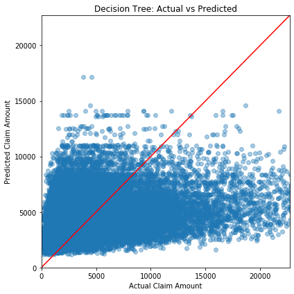

```python
plt.figure(figsize=(6,6))

plt.scatter(
    y_test,
    y_pred_tree,
    alpha=0.4
)

plt.plot(
    [y_test.min(), y_test.max()],
    [y_test.min(), y_test.max()],
    color="red"
)

upper = np.percentile(y_test,99)

plt.xlim(0,upper)
plt.ylim(0,upper)

plt.xlabel("Actual Claim Amount")
plt.ylabel("Predicted Claim Amount")

plt.title("Decision Tree: Actual vs Predicted")

plt.tight_layout()
plt.show()
```

## Observation

The Decision Tree model captures non-linear relationships between policy characteristics and claim severity.

However, on the unseen test data, predictive performance is slightly lower than the baseline Linear Regression model.

This indicates that a single decision tree tends to overfit the training data and does not generalise well to new policyholders.

These findings motivate the use of ensemble learning methods, such as Random Forest, which reduce model variance while preserving the ability to model complex interactions.

## Random Forest

### Objective

Develop a Random Forest Regression model to improve predictive performance by combining multiple decision trees.

Random Forest reduces overfitting through bootstrap sampling and feature randomness, making it one of the most widely used algorithms for insurance pricing and claim severity prediction.

This model serves as the primary benchmark for evaluating non-linear predictive performance.

### Import Libraries

```python
from sklearn.ensemble import RandomForestRegressor

from sklearn.metrics import (
    mean_absolute_error,
    mean_squared_error,
    r2_score
)
```

### Train Model

```python
rf_model = RandomForestRegressor(
    n_estimators=200,
    max_depth=15,
    min_samples_leaf=10,
    random_state=42,
    n_jobs=-1
)

rf_model.fit(
    X_train,
    y_train
)
```

```
RandomForestRegressor(bootstrap=True, ccp_alpha=0.0, criterion='mse',
                      max_depth=15, max_features='auto', max_leaf_nodes=None,
                      max_samples=None, min_impurity_decrease=0.0,
                      min_impurity_split=None, min_samples_leaf=10,
                      min_samples_split=2, min_weight_fraction_leaf=0.0,
                      n_estimators=200, n_jobs=-1, oob_score=False,
                      random_state=42, verbose=0, warm_start=False)
```

### Prediction

```python
y_pred_rf = rf_model.predict(X_test)
```

### Performance Evaluation

```python
rf_mae = mean_absolute_error(
    y_test,
    y_pred_rf
)

rf_rmse = mean_squared_error(
    y_test,
    y_pred_rf,
    squared=False
)

rf_r2 = r2_score(
    y_test,
    y_pred_rf
)
```

```python
performance["Random Forest"] = [

    rf_mae,

    rf_rmse,

    rf_r2

]

performance
```

|  | Metric | Linear Regression | Decision Tree | Random Forest |
| --- | --- | --- | --- | --- |
| 0 | MAE | 2757.519297 | 2776.952036 | 2773.200495 |
| 1 | RMSE | 4371.865296 | 4403.480046 | 4396.576437 |
| 2 | R² | 0.130945 | 0.118331 | 0.121093 |

### Actual vs Predicted

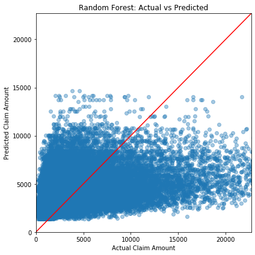

```python
plt.figure(figsize=(6,6))

plt.scatter(
    y_test,
    y_pred_rf,
    alpha=0.4
)

plt.plot(
    [y_test.min(), y_test.max()],
    [y_test.min(), y_test.max()],
    color="red"
)

upper = np.percentile(y_test,99)

plt.xlim(0,upper)
plt.ylim(0,upper)

plt.xlabel("Actual Claim Amount")
plt.ylabel("Predicted Claim Amount")

plt.title("Random Forest: Actual vs Predicted")

plt.tight_layout()

plt.show()
```

### Feature Importance

```python
feature_importance = (

    pd.Series(
        rf_model.feature_importances_,
        index=X_train.columns
    )

    .sort_values(ascending=False)

)
```

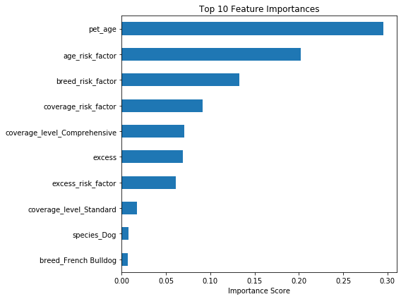

```python
plt.figure(figsize=(8,6))

feature_importance.head(10).sort_values().plot(

    kind="barh"

)

plt.title("Top 10 Feature Importances")

plt.xlabel("Importance Score")

plt.tight_layout()

plt.show()
```

### Observation

Random Forest achieves slightly better predictive performance than a single Decision Tree by reducing overfitting through ensemble learning.

However, the model does not outperform the baseline Linear Regression model on the test dataset.

This suggests that the engineered claim severity in the current dataset is largely driven by approximately linear relationships between age, breed and policy characteristics.

Feature importance analysis indicates that pet age remains the strongest predictor of expected claim severity, followed by age-related risk factors and breed-related variables.

Overall, Random Forest provides greater interpretability of feature importance while demonstrating competitive predictive performance.

## Gradient Boosting Regressor

### Objective

Develop a Gradient Boosting Regression model to evaluate whether sequential ensemble learning can improve claim severity prediction.

Unlike Random Forest, which builds trees independently, Gradient Boosting builds trees sequentially, where each new tree attempts to correct the errors of the previous model.

This model provides a final comparison against Linear Regression, Decision Tree and Random Forest.

```python
from sklearn.ensemble import GradientBoostingRegressor
```

```python
gb_model = GradientBoostingRegressor(
    n_estimators=200,
    learning_rate=0.05,
    max_depth=3,
    min_samples_leaf=10,
    random_state=42
)

gb_model.fit(
    X_train,
    y_train
)
```

```
GradientBoostingRegressor(alpha=0.9, ccp_alpha=0.0, criterion='friedman_mse',
                          init=None, learning_rate=0.05, loss='ls', max_depth=3,
                          max_features=None, max_leaf_nodes=None,
                          min_impurity_decrease=0.0, min_impurity_split=None,
                          min_samples_leaf=10, min_samples_split=2,
                          min_weight_fraction_leaf=0.0, n_estimators=200,
                          n_iter_no_change=None, presort='deprecated',
                          random_state=42, subsample=1.0, tol=0.0001,
                          validation_fraction=0.1, verbose=0, warm_start=False)
```

```python
y_pred_gb = gb_model.predict(X_test)
```

```python
gb_mae = mean_absolute_error(
    y_test,
    y_pred_gb
)

gb_rmse = mean_squared_error(
    y_test,
    y_pred_gb,
    squared=False
)

gb_r2 = r2_score(
    y_test,
    y_pred_gb
)
```

```python
performance["Gradient Boosting"] = [
    gb_mae,
    gb_rmse,
    gb_r2
]

performance
```

|  | Metric | Linear Regression | Decision Tree | Random Forest | Gradient Boosting |
| --- | --- | --- | --- | --- | --- |
| 0 | MAE | 2757.519297 | 2776.952036 | 2773.200495 | 2747.881884 |
| 1 | RMSE | 4371.865296 | 4403.480046 | 4396.576437 | 4358.185500 |
| 2 | R² | 0.130945 | 0.118331 | 0.121093 | 0.136375 |

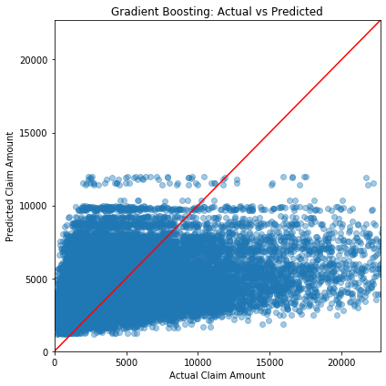

```python
plt.figure(figsize=(6,6))

plt.scatter(
    y_test,
    y_pred_gb,
    alpha=0.4
)

plt.plot(
    [y_test.min(), y_test.max()],
    [y_test.min(), y_test.max()],
    color="red"
)

upper = np.percentile(y_test, 99)

plt.xlim(0, upper)
plt.ylim(0, upper)

plt.xlabel("Actual Claim Amount")
plt.ylabel("Predicted Claim Amount")

plt.title("Gradient Boosting: Actual vs Predicted")

plt.tight_layout()
plt.show()
```

```python
gb_feature_importance = (
    pd.Series(
        gb_model.feature_importances_,
        index=X_train.columns
    )
    .sort_values(ascending=False)
)

gb_feature_importance.head(10)
```

```
age_risk_factor                 0.281020
pet_age                         0.227796
coverage_risk_factor            0.151506
breed_risk_factor               0.134006
excess_risk_factor              0.080381
coverage_level_Comprehensive    0.066935
excess                          0.055449
breed_Dachshund                 0.001889
breed_French Bulldog            0.000205
breed_Siamese                   0.000156
dtype: float64
```

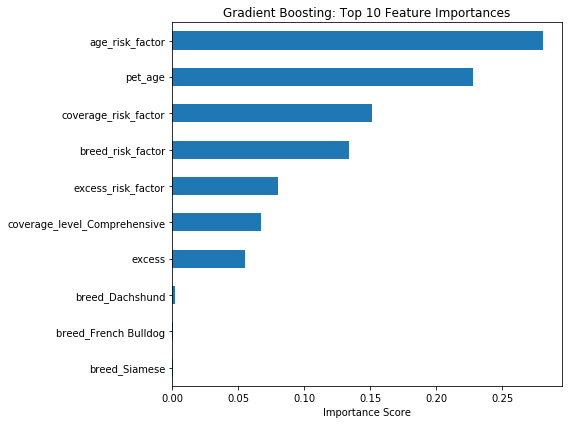

```python
plt.figure(figsize=(8,6))

gb_feature_importance.head(10).sort_values().plot(
    kind="barh"
)

plt.title("Gradient Boosting: Top 10 Feature Importances")
plt.xlabel("Importance Score")

plt.tight_layout()
plt.show()
```

### Observation

Gradient Boosting identifies age-related variables as the strongest drivers of expected claim severity.

The engineered age risk factor and pet age contribute the largest share of predictive power, followed by coverage risk and breed risk.

Policy characteristics such as coverage level and excess remain important predictors, while individual breed indicators contribute relatively less once broader risk factors are included.

Overall, the feature importance rankings are broadly consistent with the previous risk segmentation analysis, providing additional confidence that age and policy design are the primary drivers of claim severity.

## Model Comparison

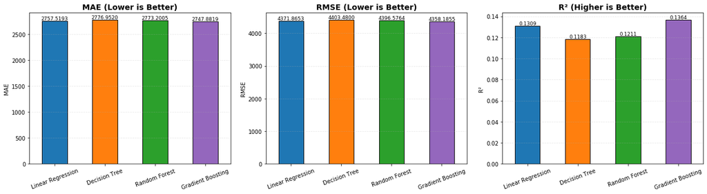

| Metric | MAE | RMSE | R² |
| --- | --- | --- | --- |
| Linear Regression | 2757.5193 | 4371.8653 | 0.1309 |
| Decision Tree | 2776.9520 | 4403.4800 | 0.1183 |
| Random Forest | 2773.2005 | 4396.5764 | 0.1211 |
| Gradient Boosting | 2747.8819 | 4358.1855 | 0.1364 |

```python
perf_df = performance.set_index("Metric").T

# Round values for display
perf_df = perf_df.round(4)

fig, axes = plt.subplots(1, 3, figsize=(18, 5))

metrics = ["MAE", "RMSE", "R²"]
titles = [
    "MAE (Lower is Better)",
    "RMSE (Lower is Better)",
    "R² (Higher is Better)"
]

colors = ["#1f77b4", "#ff7f0e", "#2ca02c", "#9467bd"]

for ax, metric, title in zip(axes, metrics, titles):

    perf_df[metric].plot(
        kind="bar",
        ax=ax,
        color=colors,
        edgecolor="black"
    )

    ax.set_title(title, fontsize=14, weight="bold")
    ax.set_ylabel(metric)
    ax.grid(axis="y", linestyle="--", alpha=0.3)
    ax.tick_params(axis="x", rotation=20)

    for p in ax.patches:
        height = p.get_height()

        ax.annotate(
            f"{height:.4f}",
            (p.get_x() + p.get_width()/2, height),
            ha="center",
            va="bottom",
            fontsize=9
        )

plt.tight_layout()
plt.show()

display(perf_df)
```

### Observation

Gradient Boosting achieved the best overall predictive performance among the four regression models.

Compared with Linear Regression, Decision Tree and Random Forest, Gradient Boosting produced the lowest MAE and RMSE together with the highest R² value.

Although the improvement is relatively modest, the results indicate that sequential boosting better captures the non-linear relationships between pet characteristics, policy design and claim severity.

Overall, Gradient Boosting is selected as the preferred model for claim severity prediction in this project.

## Executive Summary

This notebook compared four supervised machine learning models for predicting expected pet insurance claim severity.

The objective was to evaluate whether more advanced ensemble learning methods improve predictive performance over a simple Linear Regression benchmark.

Four regression models were evaluated:

- Linear Regression
- Decision Tree
- Random Forest
- Gradient Boosting Regressor

Performance was assessed using Mean Absolute Error (MAE), Root Mean Squared Error (RMSE) and R².

Among the evaluated models, Gradient Boosting achieved the best overall predictive performance, producing the lowest prediction error and the highest explanatory power.

Feature importance analysis consistently identified age-related variables as the strongest drivers of claim severity, followed by coverage design and breed risk. These findings are consistent with the earlier exploratory analysis and support the business assumption that both customer characteristics and policy structure influence expected insurance costs.

The resulting model can support actuarial pricing, underwriting decision-making and customer risk segmentation by providing more accurate estimates of expected claim costs.